# Time Series Anlaysis. Practice 2. Descriptive statistics

Miguel Albertí Pons, Iker González Cuellar, Pol Martínez Collado

25-01-23

```r
library(dplyr)
library(tidyr)
library(reshape2)
library(magrittr)
library(stringr)
library(astsa)
```

# **Ejercicio 1:**

**Read the IPC data as you did in the last homework. Then compute the Inflation as Inflation <- 100*diff(IPC,lag=12)/lag(IPC,k=-12) and the regularly and seasonally differentiated IPC time series as IPC.d1.d12 <- diff( diff(IPC,lag=12), lag=1).**

```r
ipcDataRaw = read.csv("_repository/INE_IPC.csv", sep = ",")

# IPC INDEX
# ----------------------------------
table_range = 1:196
ipcIndex = ipcDataRaw[c(6,7),table_range]
names(ipcIndex) = ipcIndex[1,]
ipcIndex = ipcIndex[-1,] %>% rename(., id = 1) %>% melt(., id = "id") %>% rename(., date = 2, index = 3) %>% .[,2:3] %>% arrange(., desc(date)) %>% transform(., index = as.double(index), date = as.Date(date))
ipcIndex.ts = ts(ipcIndex[2], frequency = 12, start=c(2002,01))

# Inflation
# ----------------------------------
divisor = lag(ipcIndex[,2],k=-12)
dividendo = 100*diff(ipcIndex[,2],lag=12)
Inflation = suppressWarnings(ts(dividendo/divisor, frequency = 12, start=c(2002,01)))
Inflation = na.omit(Inflation)


# seasonally differentiated IPC TS
# ----------------------------------
IPC.d1.d12 = diff(diff(ipcIndex.ts,lag=12), lag=1)
```

# **Ejercicio 2:**

**Do the structural decomposition of the following time series:**

**• IPC**

**• Monthly variation of th IPC.**

**• Inflation (100*diff(IPC,lag=12)/lag(IPC,k=-12)).**

**• The IPC series, differentiated regularly and seasonally: IPC.d1.d12.**

**Use first decompose and stl, plot the obtaind components and do a barplot of the one-year seasonal component.**

**Then use the function HoltWinters from package astsa.**

```r
# Monthly variation of IPC index Transformación
# ----------------------------------
table_range = 197:390
IPCmonthVariation = ipcDataRaw[c(6,7),table_range]
names(IPCmonthVariation) = IPCmonthVariation[1,]
IPCmonthVariation = IPCmonthVariation[-1,] %>% rename(., id = 1) %>% melt(., id = "id") %>% rename(., date = 2, index = 3) %>% .[,2:3]  %>% arrange(., desc(date)) %>% transform(., index = as.double(index), date = as.Date(date))
IPCmonthVariation.ts = ts(IPCmonthVariation[2], frequency = 12, start=c(2002,01))
```

```r
# decompose
ipc_decompose = decompose(ipcIndex.ts)
monthly_decompose_ipc = decompose(IPCmonthVariation.ts)
inflation_decompose = decompose(Inflation)
IPC.d1.d12_decompose = decompose(IPC.d1.d12[,1])

# stl
ipc_stl = stl(ipcIndex.ts[,1], s.window = "periodic")
monthly_stl_ipc = stl(IPCmonthVariation.ts[,1], s.window = "periodic")
inflation_stl = stl(Inflation, s.window = "periodic")
IPC.d1.d12_stl = stl(IPC.d1.d12[,1], s.window = "periodic")

# HoltWinters
HoltWinters(ipcIndex.ts, beta=FALSE)
```

```
## Holt-Winters exponential smoothing without trend and with additive seasonal component.
##
## Call:
## HoltWinters(x = ipcIndex.ts, beta = FALSE)
##
## Smoothing parameters:
##  alpha: 0.9440086
##  beta : FALSE
##  gamma: 1
##
## Coefficients:
##            [,1]
## a   102.1802133
## s1    0.8686856
## s2    0.6711556
## s3    0.4604174
## s4   -0.3197610
## s5   -0.2497500
## s6   -0.2336821
## s7    0.3580019
## s8    0.3754544
## s9    0.2964592
## s10  -0.5207183
## s11  -0.3176991
## s12   0.1487867
```

```r
HoltWinters(IPCmonthVariation.ts, beta=FALSE)
```

```
## Holt-Winters exponential smoothing without trend and with additive seasonal component.
##
## Call:
## HoltWinters(x = IPCmonthVariation.ts, beta = FALSE)
##
## Smoothing parameters:
##  alpha: 0.07341714
##  beta : FALSE
##  gamma: 0.2182184
##
## Coefficients:
##            [,1]
## a    0.16672458
## s1   0.30810430
## s2   0.81030452
## s3   0.05238885
## s4   0.03050757
## s5  -0.80687910
## s6   0.01319790
## s7  -0.03294076
## s8   0.63838519
## s9   0.15119583
## s10 -0.09890698
## s11 -1.26764339
## s12 -0.19119465
```

```r
HoltWinters(Inflation, beta=FALSE)
```

```
## Holt-Winters exponential smoothing without trend and with additive seasonal component.
##
## Call:
## HoltWinters(x = Inflation, beta = FALSE)
##
## Smoothing parameters:
##  alpha: 0.9636877
##  beta : FALSE
##  gamma: 1
##
## Coefficients:
##            [,1]
## a    2.59969430
## s1  -0.27841910
## s2   0.16295121
## s3   0.42216838
## s4   0.35953211
## s5   0.23728104
## s6   0.22643827
## s7   0.11591705
## s8   0.12850565
## s9   0.01180047
## s10 -0.27892754
## s11 -0.48807771
## s12 -0.62039718
```

```r
HoltWinters(IPC.d1.d12, beta=FALSE)
```

```
## Holt-Winters exponential smoothing without trend and with additive seasonal component.
##
## Call:
## HoltWinters(x = IPC.d1.d12, beta = FALSE)
##
## Smoothing parameters:
##  alpha: 0.2181693
##  beta : FALSE
##  gamma: 0.1401774
##
## Coefficients:
##             [,1]
## a    0.028214978
## s1   0.048453627
## s2   0.059407850
## s3   0.027082164
## s4  -0.009153269
## s5   0.063905846
## s6   0.043218725
## s7   0.019408810
## s8   0.053489186
## s9  -0.032351500
## s10 -0.081747676
## s11 -0.047997839
## s12 -0.091997670
```

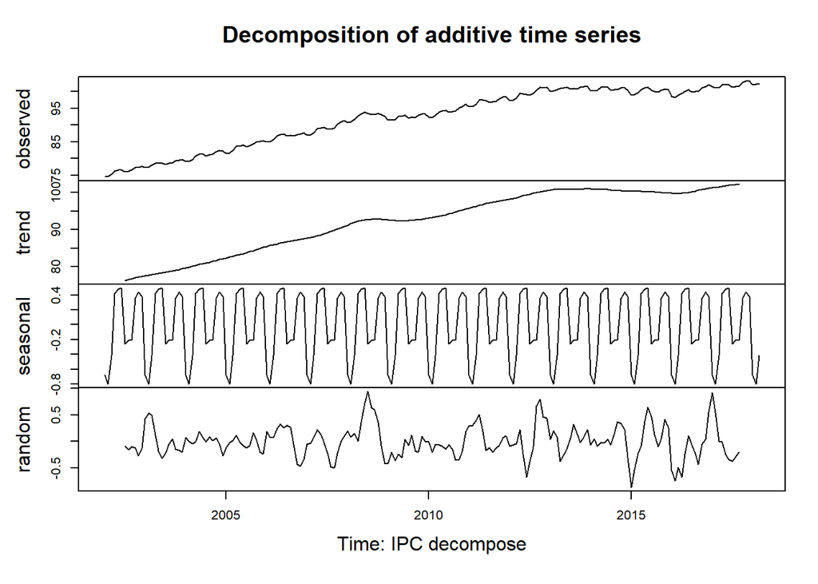

```r
# decompose graficos
plot(ipc_decompose, xlab='Time: IPC decompose')
```

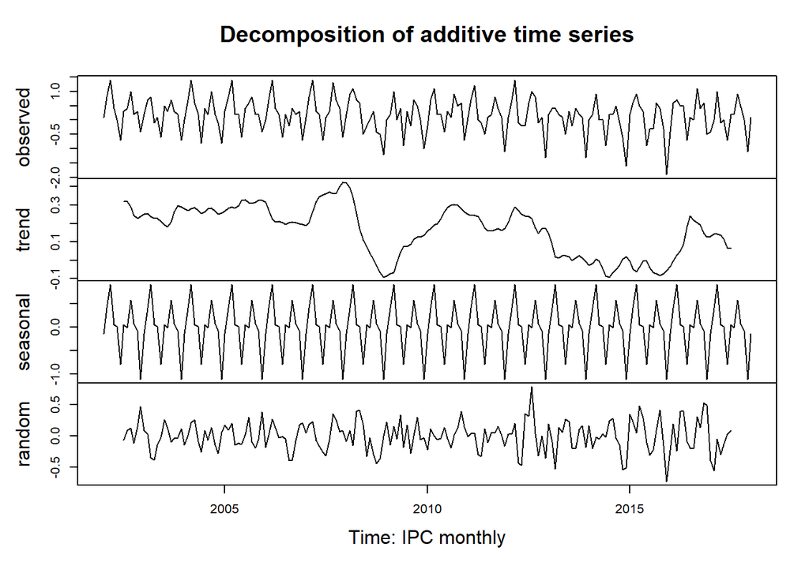

```r
plot(monthly_decompose_ipc, xlab='Time: IPC monthly')
```

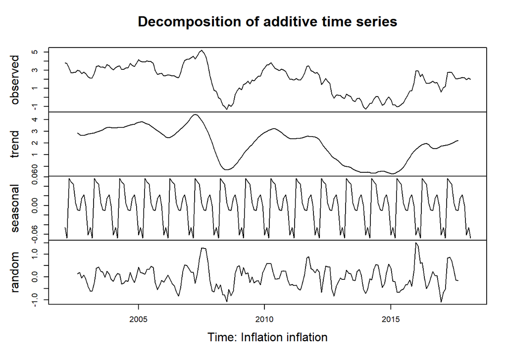

```r
plot(inflation_decompose, xlab='Time: Inflation inflation')
```

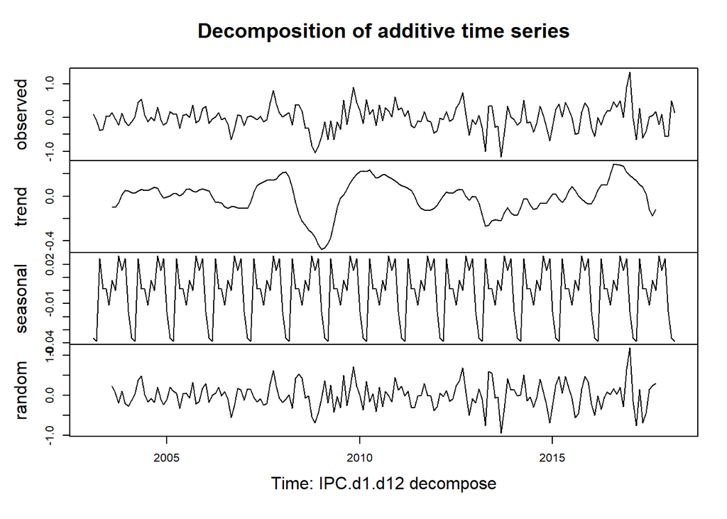

```r
plot(IPC.d1.d12_decompose, xlab='Time: IPC.d1.d12 decompose')
```

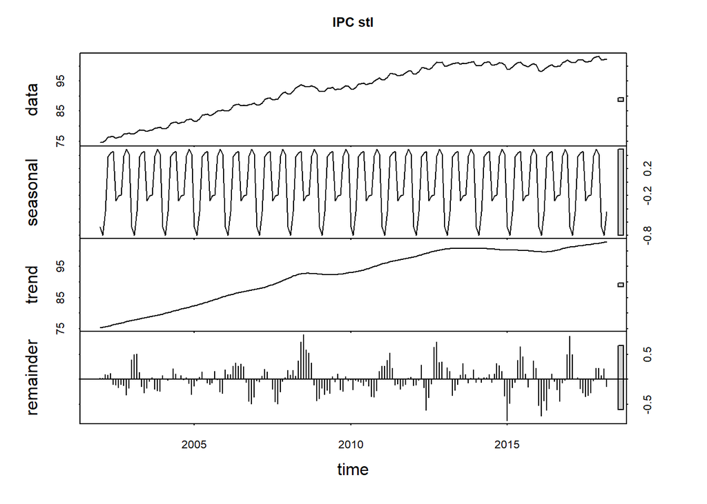

```r
# stl graficos
plot_ipc_stl = plot(ipc_stl, main="IPC stl")
```

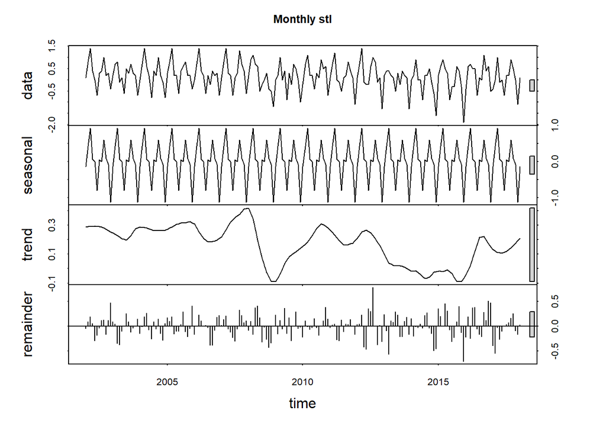

```r
plot(monthly_stl_ipc, main="Monthly stl")
```

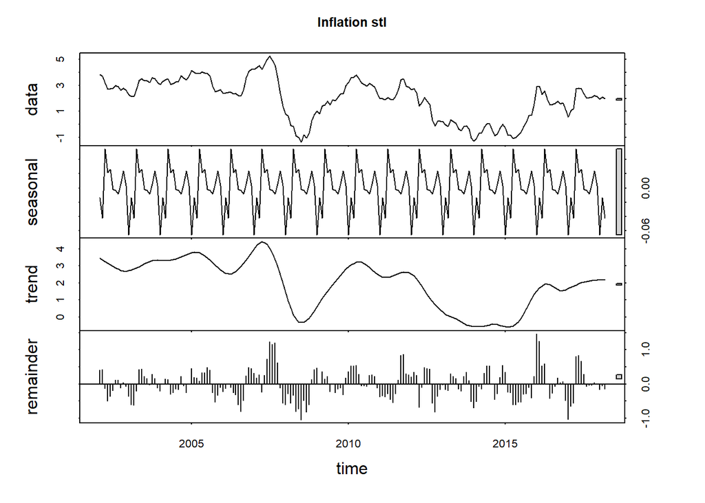

```r
plot(inflation_stl, main="Inflation stl")
```

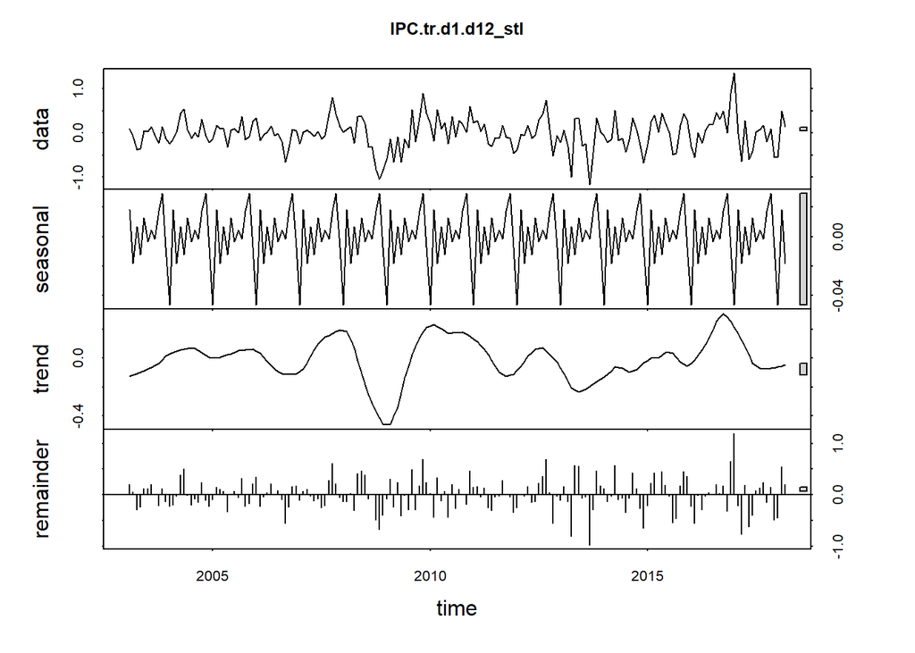

```r
plot(IPC.d1.d12_stl, main="IPC.tr.d1.d12_stl")
```

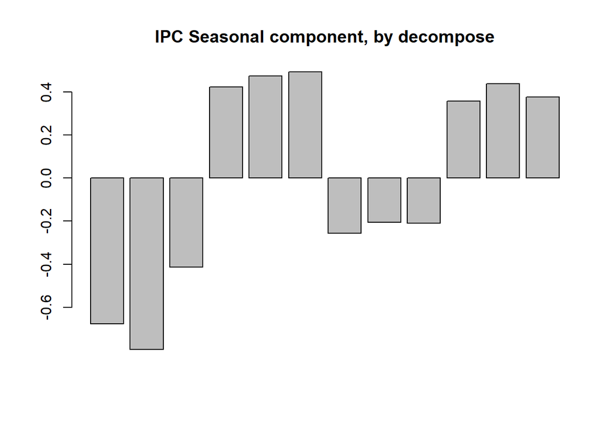

```r
# Barplot one-year seasonal component
barplot(ipc_decompose$figure, main="IPC Seasonal component, by decompose")
```

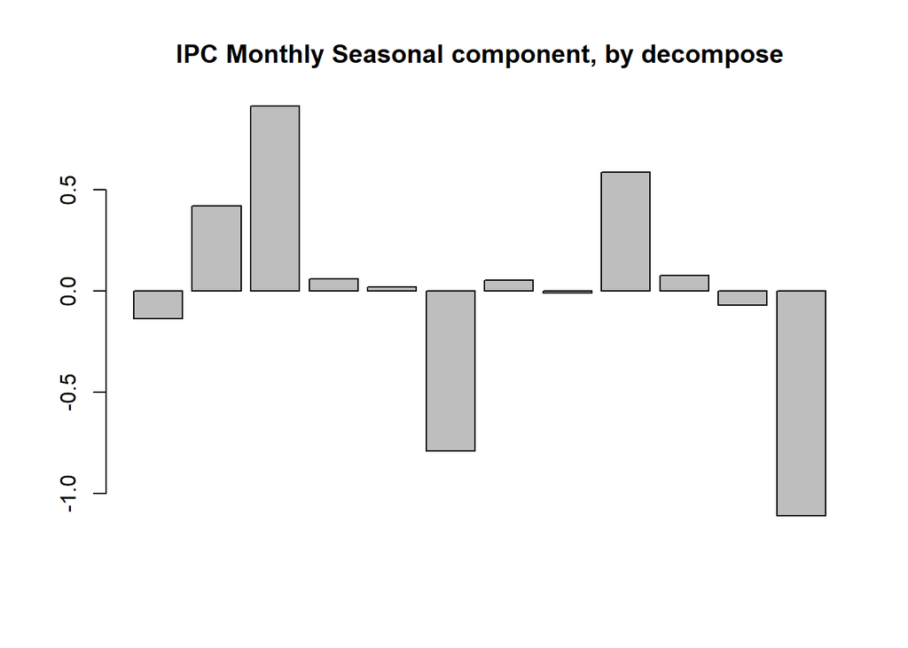

```r
barplot(monthly_decompose_ipc$figure, main="IPC Monthly Seasonal component, by decompose")
```

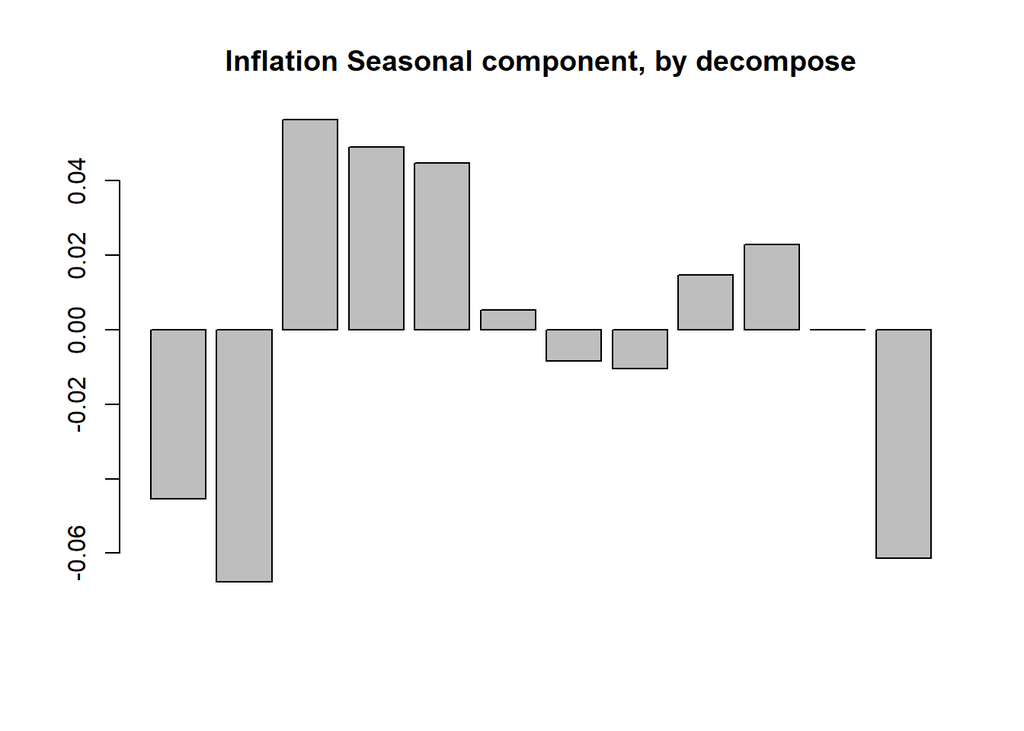

```r
barplot(inflation_decompose$figure, main="Inflation Seasonal component, by decompose")
```

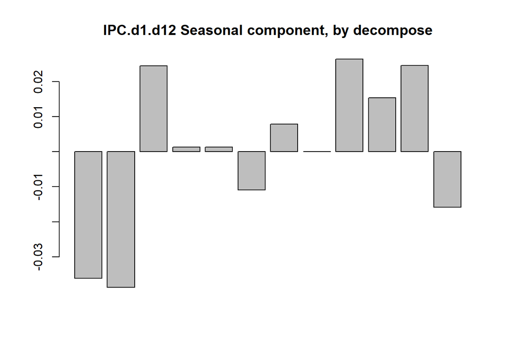

```r
barplot(IPC.d1.d12_decompose$figure, main="IPC.d1.d12 Seasonal component, by decompose")
```

# **Ejercicio 3:**

**Using the function window, cut the time series IPC in two parts: a training part until December 2016, and a test part from January 2017. Call them IPC.tr and IPC.te, respectively.**

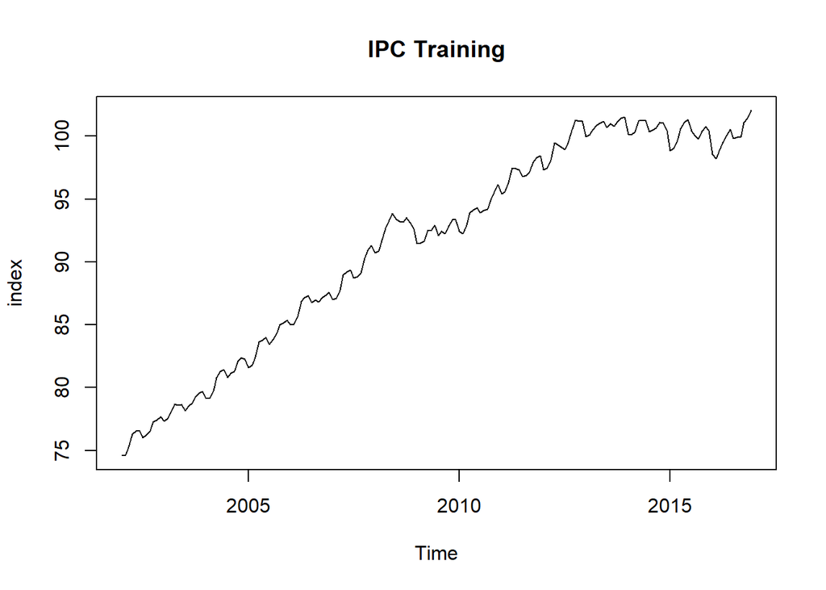

```r
end.tr = c(2016,12)
IPC.tr = window(ipcIndex.ts, end = end.tr)

start.te = c(2017,1)
IPC.te = window(ipcIndex.ts, start = start.te)

plot(IPC.tr, main="IPC Training")
```

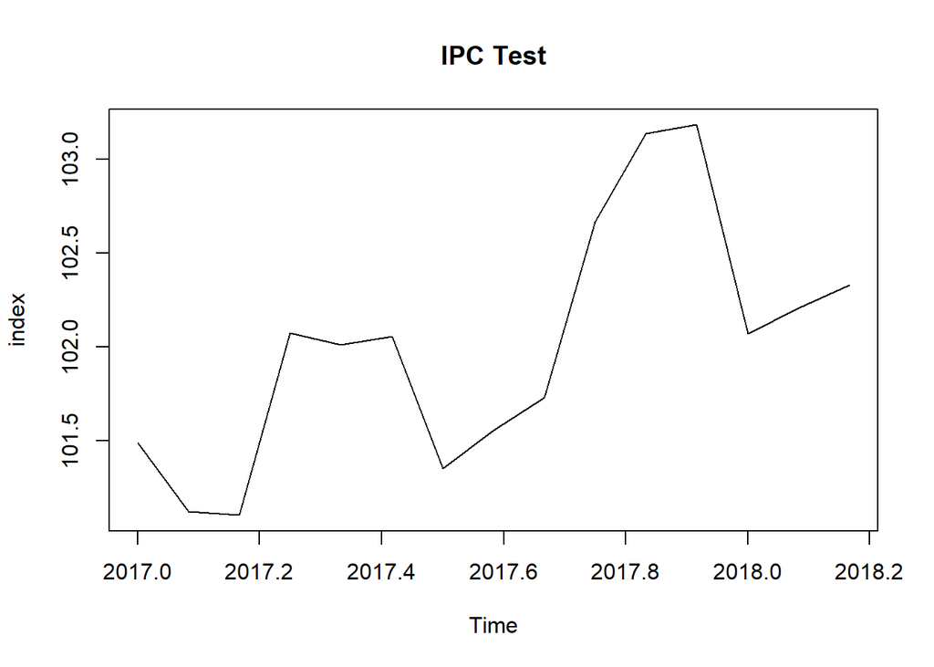

```r
plot(IPC.te, main="IPC Test")
```

# **Ejercio 4:**

**Compute the regular and seasonal difference of IPC.tr and call the resulting series IPC.tr.d1.d12.**

**a. Plot this series, as well as its ACF and its PACF.**

**b. Do you think IPC.tr.d1.d12 is white noise?**

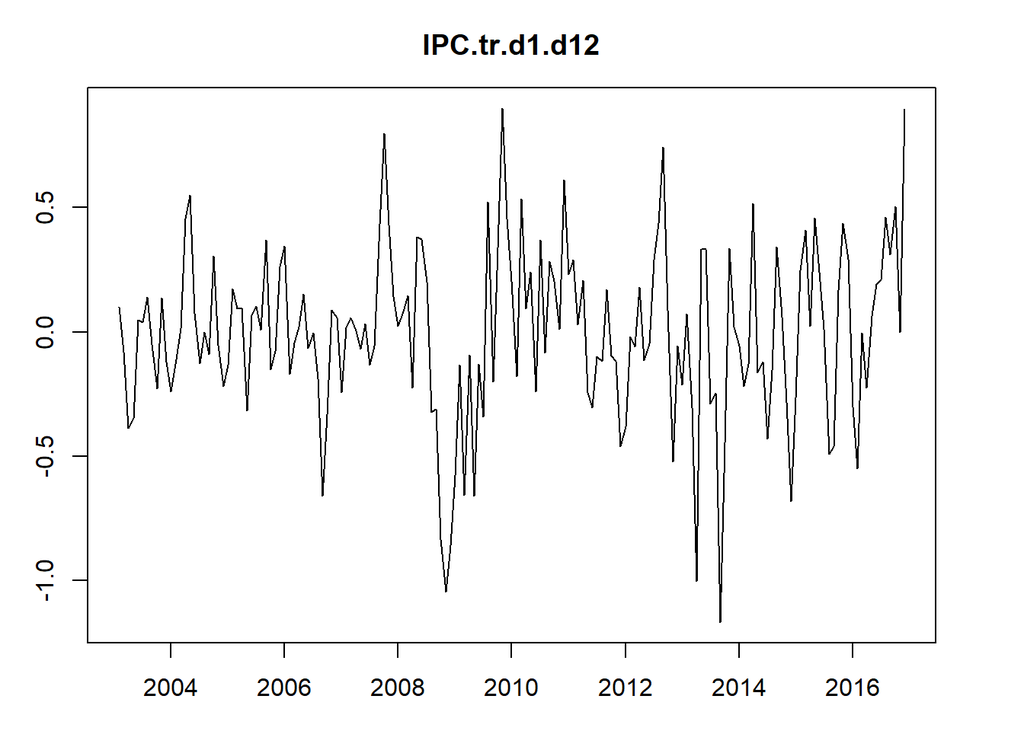

```r
IPC.tr.d1.d12 = diff(diff(IPC.tr,lag=1), lag=12)

par(mfrow = c(1,1), mar = c(rep(3,4)))
plot(IPC.tr.d1.d12, main = 'IPC.tr.d1.d12')
```

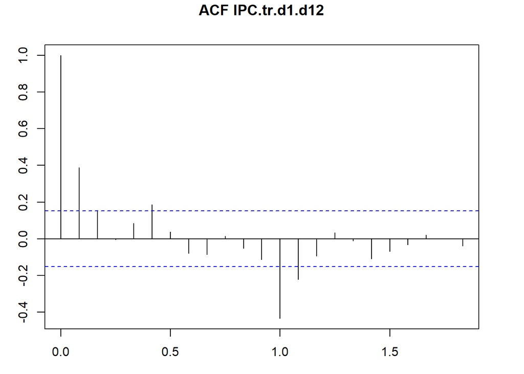

```r
acf(IPC.tr.d1.d12, main = 'ACF IPC.tr.d1.d12')
```

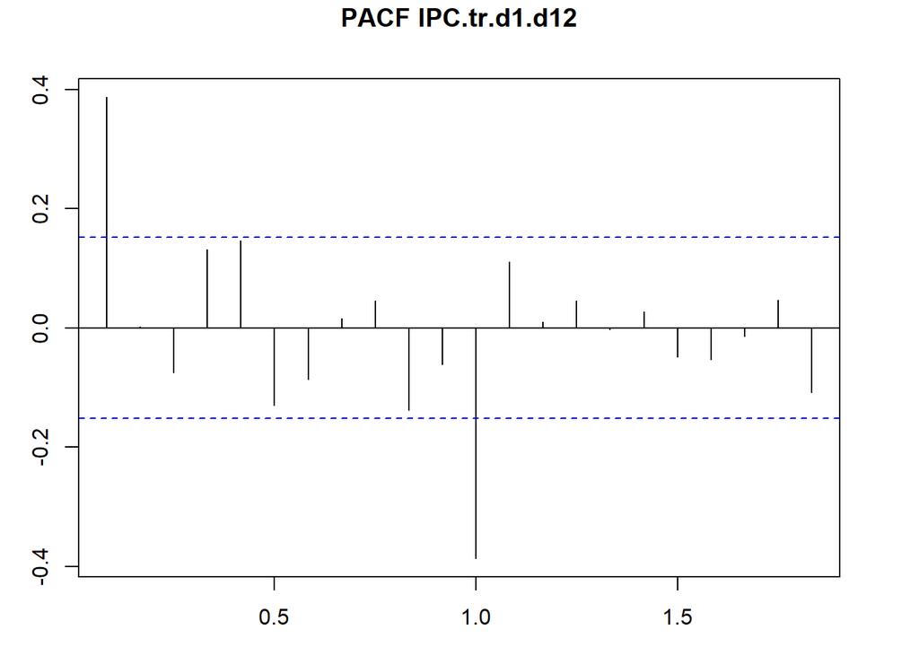

```r
pacf(IPC.tr.d1.d12, main = 'PACF IPC.tr.d1.d12')
```

Observando el gráfico de autocorrelación podríamos concluir que no es White Noise, ya que existe una correlación positiva en por lo menos 1 retardo en el calculo del ACF (lag 1). Para poder considerar que las observaciones son ruidos blancos, todas la observaciones en el ACF deberían ser próximas a cero para considerarlas independientes e identicamentes distribuidas.

# **Ejercicio 5:**

**Use the functions HoltWinters (with the default parameters) and predict.HoltWinters to predict the next 15 values of IPC.tr.d1.d12 (these are the forecasting of the values corresponding to the period from January 2017 to March 2018). Plot the forecasted object.**

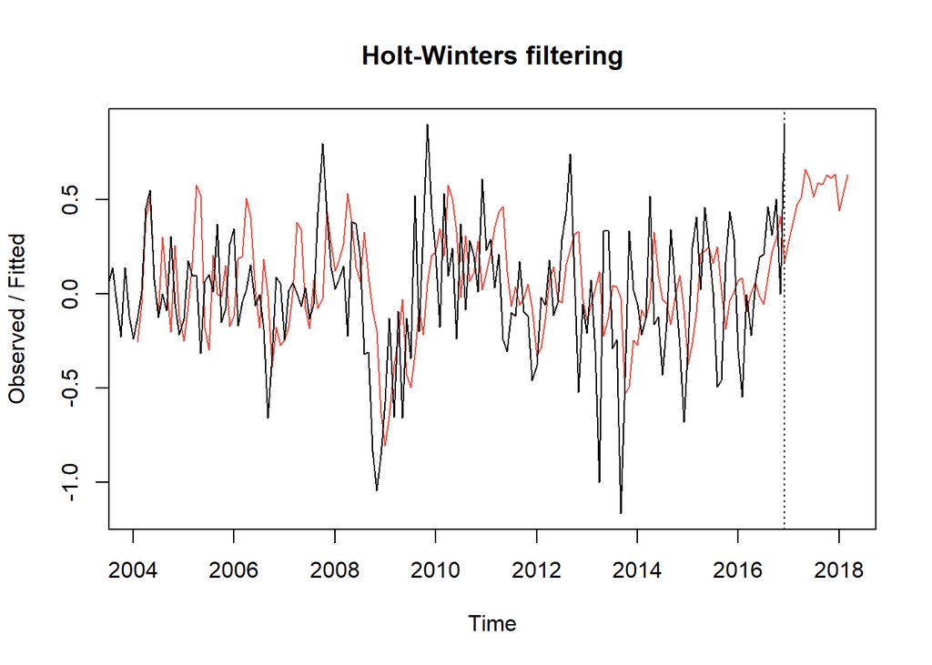

```r
#Holt Winters
IPC.tr.d1.d12.HW = HoltWinters(IPC.tr.d1.d12)

#Holt Winters Prediction
IPC.tr.d1.d12.HWP = predict(IPC.tr.d1.d12.HW, 15)

plot(IPC.tr.d1.d12.HW, IPC.tr.d1.d12.HWP)
```

# **Ejercicio 6:**

**Use the functions HoltWinters (with the default parameters) and predict.HoltWinters to predict the next 15 values of IPC.tr (these are the forecasting of the values corresponding to the period from January 2017 to March 2018).**

**a. Plot the forecasted object.**

**b. Compare these predictions with the values of of the test values in IPC.te.**

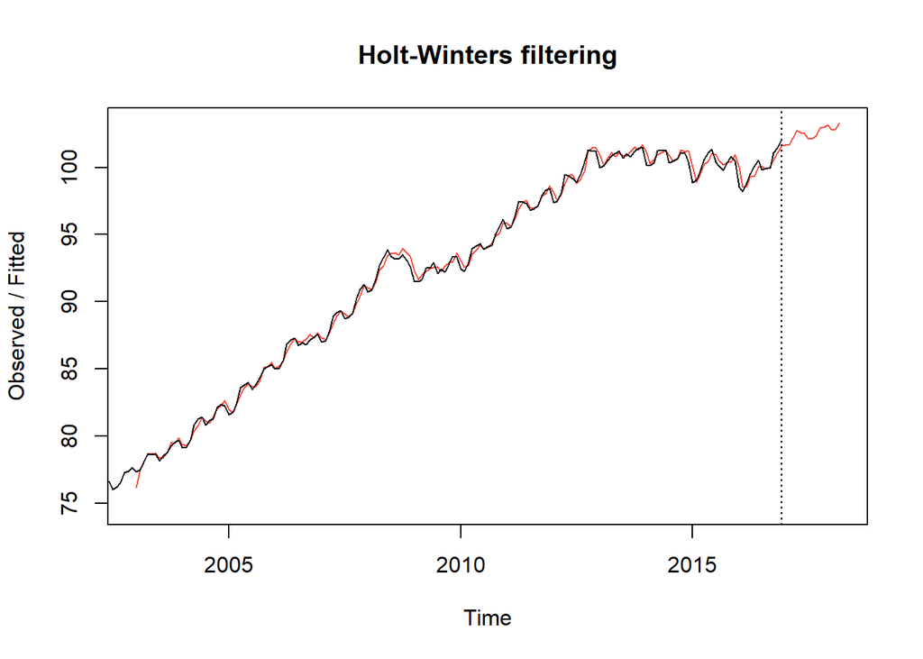

```r
#a.

#Holt Winters
IPC.tr.HW = HoltWinters(IPC.tr)

#Holt Winters Prediction
IPC.tr.HWP = predict(IPC.tr.HW, 15)
plot(IPC.tr.HW, IPC.tr.HWP)
```

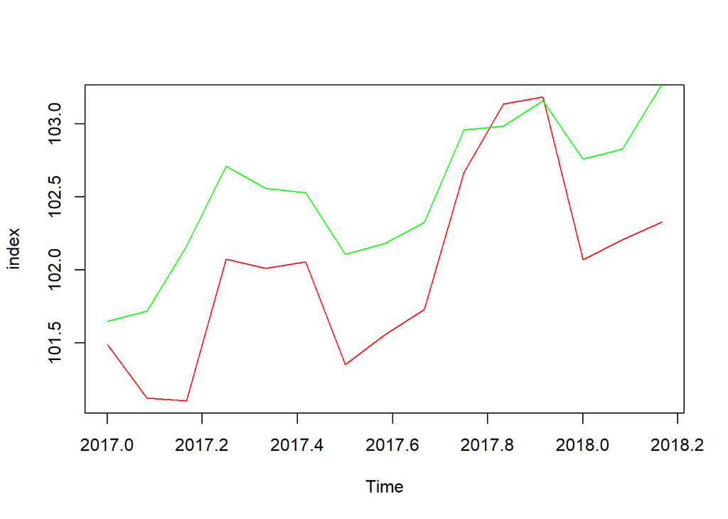

```r
#b.

#Comparison
plot(IPC.te,type="l",col="red")
lines(IPC.tr.HWP,col="green")
```

```r
#Summary difference predicted vs real observations
IPCpredicted = data.frame(IPC.tr.HWP)
IPCreal = data.frame(IPC.te)

differencePvsR = IPCpredicted-IPCreal

summary(differencePvsR)
```

```
##       fit
##  Min.   :-0.1520
##  1st Qu.: 0.3825
##  Median : 0.5962
##  Mean   : 0.5215
##  3rd Qu.: 0.6631
##  Max.   : 1.0598
```

La predicción de Holt Winters (verde) acierta en la tendencia seasonal y en la tendencia general al alza pero es más optimista y da valores mas altos que los reales con una diferencia media de 0.5215 puntos.